# STAT 252 — In-Class Experiments

Guided Analysis Workbook

Author

Cal Poly San Luis Obispo

Published

April 8, 2026

# How to Use This Workbook

This workbook walks through three in-class experiments using the **SSVA framework** (Summary statistics → Visualization → Analysis). For each experiment we will:

1. **State the research question.**
2. **Look at the raw data** directly in the Google Sheet.
3. **Examine summary statistics.**
4. **Interpret the visualization.**
5. **Run the analysis** (hypothesis test + confidence interval).
6. **Answer SSVA guiding questions** as a class.
7. **Answer independent conceptual questions** on your own.

**Session code:** `sec-08`  
**Class Google Sheet:** [open in new tab](https://docs.google.com/spreadsheets/d/12isb_SuqqKsMgHAhzOJIzwagqZaXadsU4oFZZUhHuv0/edit)  
**Report generated:** April 08, 2026 at 03:54 PM

**Tip**

**Before each experiment:** open the class Google Sheet linked above and click the tab for that experiment (`reaction`, `memory`, or `framing`) to see the raw data you helped collect.

# 1 Experiment 1 — Two Independent Population Means

## 1.1 Research Question

> **Does listening to music while performing a simple task change how quickly people can react?**

## 1.2 Step 1 — Look at the Raw Data

**Note**

**Open the class Google Sheet and click the `reaction` tab.** Look at how each row is a single student, with their assigned group and their average reaction time across 5 trials. How many rows do you see? How are students split between the two groups?

First few rows of the reaction time data (for reference)

| Group | Average RT (ms) |
| --- | --- |
| music | 579 |
| music | 507 |
| silence | 711 |
| silence | 436 |
| silence | 308 |
| silence | 381 |

## 1.3 Step 2 — Summary Statistics

Summary statistics by group

| Group | n | Mean (ms) | SD (ms) | Median (ms) | Min | Max |
| --- | --- | --- | --- | --- | --- | --- |
| music | 19 | 544.5 | 181.6 | 507 | 298 | 947 |
| silence | 25 | 598.9 | 230.4 | 539 | 308 | 1327 |

## 1.4 Step 3 — Visualization

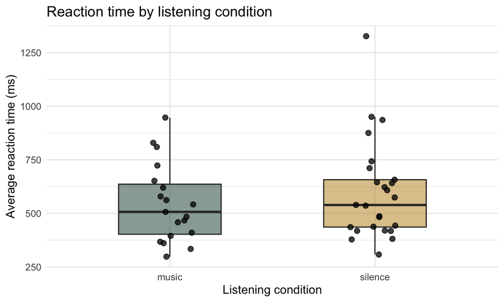

## 1.5 Step 4 — Analysis

Welch two-sample t-test: music vs. silence

| Quantity | Value |
| --- | --- |
| Test statistic (t) | -0.877 |
| Degrees of freedom | 41.92 |
| p-value | 0.3857 |
| 90% CI lower | -158.92 |
| 90% CI upper | 50.03 |

## 1.6 SSVA Guiding Questions — Experiment 1

**Q1.** How many variables are present in this experiment?

**Click to reveal answer**

Two variables: listening condition (group) and average reaction time.

**Q2.** What are the types of each variable?

**Click to reveal answer**

- **Listening condition** (music / silence): categorical, two levels.
- **Average reaction time in ms**: quantitative (continuous).

**Q3.** What are the response and explanatory variables?

**Click to reveal answer**

- **Explanatory**: listening condition (music vs. silence).
- **Response**: average reaction time in milliseconds.

**Q4.** What relationship is shown in the visualization? Which group appears to react faster on average, and how much overlap is there between the two distributions?

**Click to reveal answer**

The boxplot shows the median, quartiles, and spread of reaction times in each group. Compare the boxes: if one box sits noticeably lower, that group reacts faster on average. The degree of overlap between the boxes is an informal cue about how clear the difference is — more overlap means the groups look more similar, less overlap means the groups look more distinct.

**Q5.** What do the measures of center and variability tell you? Is one group more variable than the other?

**Click to reveal answer**

Compare the means and medians across groups to assess center. Compare the standard deviations to assess variability. A larger SD means reaction times in that group are more spread out — some students were much faster or slower than the group average. If the two SDs are very different, the groups have different amounts of within-group noise, which affects how we interpret the difference between them.

**Q6.** Based on the visualization and summary statistics alone, what is your *initial* conclusion about whether music affects reaction time? (Don’t look at the p-value yet.)

**Click to reveal answer**

An initial conclusion based purely on SSVA: if the two means are close and the boxes overlap substantially, the data look consistent with no real effect. If one mean is clearly lower and the boxes are mostly separated, the data suggest a real difference. The formal test in Step 4 will either support or refine this initial impression.

## 1.7 Independent Conceptual Questions — Experiment 1

**C1.** What is the statistical question?

**Click to reveal answer**

Is there a difference in the population mean reaction time between students who listen to music and students who work in silence?

**C2.** What is the population of interest?

**Click to reveal answer**

All Cal Poly students who could plausibly enroll in this course. (A broader target population — “all college students” — is a defensible answer too, but it requires a bigger leap.)

**C3.** What is the sample?

**Click to reveal answer**

The students in this section of STAT 252 who participated in the experiment.

**C4.** What is the observational unit?

**Click to reveal answer**

An individual student. Each student contributes one observation (their average reaction time across 5 trials).

**C5.** Describe all variables in the study (name, type, role).

**Click to reveal answer**

- **group** — categorical (2 levels: music, silence) — explanatory
- **avg_rt_ms** — quantitative continuous — response
- (Also recorded but not analyzed: individual trial times, timestamp, session)

**C6.** What potential confounding variables exist?

**Click to reveal answer**

Possible confounders include: time of day (and fatigue), caffeine intake, device type (phone touchscreen vs. laptop trackpad), noise level of the classroom environment even for the “silence” group, and individual differences in hand-eye coordination or prior gaming experience. Note that because of random assignment, most of these should balance out across groups on average.

**C7.** Is this an experiment or an observational study? How do you know?

**Click to reveal answer**

This is an **experiment**. Students were *randomly assigned* to the music or silence condition by the app, rather than self-selecting. Random assignment of the explanatory variable is the defining feature of an experiment.

**C8.** What design improvements could enhance the study?

**Click to reveal answer**

Possible improvements: standardize the device used (eliminate touchscreen vs. trackpad variability), control the type of music (everyone gets the same track), run more trials per student to reduce within-student noise, blind participants to the research hypothesis, and draw the sample from a broader population than a single class section.

**C9.** State the null and alternative hypotheses (in both words and symbols).

**Click to reveal answer**

**In words:** $H_0$: the population mean reaction time is the same for students listening to music and students in silence. $H_a$: the population mean reaction time differs between the two conditions.

**In symbols:** $H_0:\ \mu_{\text{music}} - \mu_{\text{silence}} = 0$ vs. $H_a:\ \mu_{\text{music}} - \mu_{\text{silence}} \neq 0$.

**C10.** Based on the test statistic and p-value, what do you conclude about $H_0$?

**Click to reveal answer**

If p < 0.10, we **reject** $H_0$ at the 10% significance level — we have evidence of a real difference in mean reaction time between the two conditions. If p ≥ 0.10, we **fail to reject** $H_0$ — the data are consistent with no real difference. Always state the conclusion in context, not just the statistical decision.

**C11.** If the confidence interval were not provided, could you infer whether 0 would be in it based on the hypothesis test decision? Explain.

**Click to reveal answer**

Yes. A two-sided hypothesis test at significance level $\alpha$ and a $(1-\alpha)$ confidence interval are mathematically equivalent: if you **reject** $H_0$ at $\alpha = 0.10$, then the 90% CI will **not** contain 0. If you **fail to reject**, the 90% CI **will** contain 0. They always agree for the same data and same $\alpha$.

# 2 Experiment 2 — Paired t-Test

## 2.1 Research Question

> **Does learning a simple chunking strategy improve short-term recall of a 14-digit sequence?**

## 2.2 Step 1 — Look at the Raw Data

**Note**

**Open the class Google Sheet and click the `memory` tab.** Each row is a single student with two scores: `score_before` (Round 1, no chunking) and `score_after` (Round 2, with chunking). Look at a few rows — does the “after” score tend to be higher, lower, or the same as “before” for each student?

First few rows of the memory data (for reference)

| Before (Round 1) | After (Round 2) | Difference |
| --- | --- | --- |
| 8 | 9 | 1 |
| 8 | 4 | -4 |
| 7 | 5 | -2 |
| 7 | 6 | -1 |
| 8 | 9 | 1 |
| 9 | 7 | -2 |

## 2.3 Step 2 — Summary Statistics

Summary statistics

| Quantity | Value |
| --- | --- |
| n (students) | 41.00 |
| Mean of the differences (after − before) | 0.39 |
| SD of the differences | 3.09 |
| Min difference | -4.00 |
| Max difference | 9.00 |
| Mean score, Round 1 (before) — for reference | 5.93 |
| Mean score, Round 2 (after) — for reference | 6.32 |

## 2.4 Step 3 — Visualization

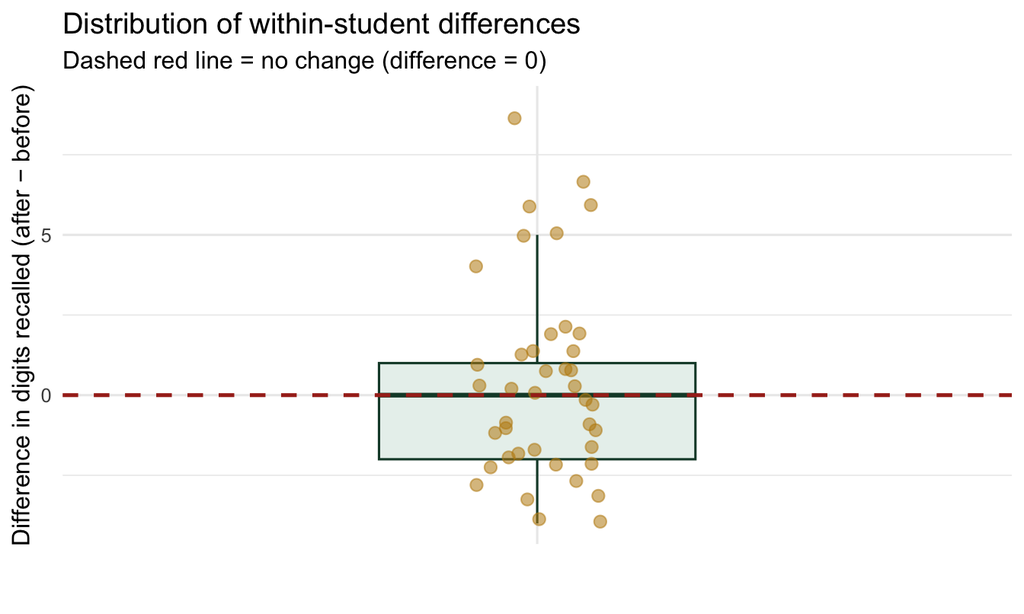

## 2.5 Step 4 — Analysis

Paired t-test: after − before chunking

| Quantity | Value |
| --- | --- |
| Test statistic (t) | 0.809 |
| Degrees of freedom | 40 |
| p-value | 0.4234 |
| 90% CI lower | -0.422 |
| 90% CI upper | 1.203 |

## 2.6 SSVA Guiding Questions — Experiment 2

**Q1.** Why does this design produce only **one variable** to analyze, even though each student has two scores?

**Click to reveal answer**

Each student has a score before and after chunking, but the paired design **subtracts** them to produce a single difference per student. That difference is the only variable the t-test uses. This is different from Experiment 1, where each student belonged to one independent group and contributed one score directly — no subtraction needed.

**Q2.** What is the variable we actually analyze in this paired design?

**Click to reveal answer**

- **The difference** (after − before): this is the **only variable the paired t-test analyzes**. It is quantitative (can be negative, zero, or positive). By computing one difference score per student, the paired design collapses the two raw measurements into a single number per observational unit. The parameter of interest is **μ_d**, the **population mean of the differences** — not the mean of “before” or “after” separately.

**Q3.** What are the explanatory and response variables?

**Click to reveal answer**

- **Explanatory**: round (before chunking vs. after chunking) — a within-subject condition.
- **Response**: number of digits recalled correctly (out of 14).

**Q4.** What does the boxplot show? What would it look like if chunking clearly helped? What if it had no effect?

**Click to reveal answer**

The boxplot displays the **distribution of within-student differences** (after − before). The dashed red line marks zero — no change. If chunking helped, the bulk of the box and most dots should be **above zero**. If it had no effect, the box should **straddle zero** with the median near zero. Individual dots above zero are students who improved; dots below zero are students who did worse in Round 2. The spread of the box tells you how consistent the effect was across students.

**Q5.** What does the **mean of the differences** tell you? What does the **SD of the differences** tell you?

**Click to reveal answer**

The **mean of the differences** estimates the population mean of the differences, μ_d — the average within-student change. A positive value means students scored higher after learning chunking, on average. The **SD of the differences** measures how much individual difference scores vary around that mean — a small SD means the effect was consistent across students; a large SD means some improved a lot while others barely changed or got worse.

**Q6.** Based on SSVA alone, what is your initial conclusion about whether chunking helps?

## 2.7 Independent Conceptual Questions — Experiment 2

**C1.** What is the statistical question?

**Click to reveal answer**

Is the **population mean of the differences** (after − before) equal to zero, or is there evidence it is different from zero?

**C2.** What is the population of interest?

**Click to reveal answer**

All Cal Poly students who could plausibly take this course.

**C3.** What is the sample?

**Click to reveal answer**

The students in this STAT 252 section who completed both rounds of the memory task.

**C4.** What is the observational unit?

**Click to reveal answer**

An individual student. Each student contributes a *pair* of scores, but the unit we’re tracking is still the student — which is exactly why this is a paired design.

**C5.** Describe all variables in the study.

**Click to reveal answer**

- **difference** (after − before) — quantitative — the **one variable we analyze**; the paired t-test operates only on this derived value.
- **score_before** and **score_after** are recorded for reference but are not directly compared by the test — they exist only to produce the difference.

**C6.** What potential confounding variables exist? Consider what’s special about a before/after design.

**Click to reveal answer**

Order effects are the main concern: the “after” round always comes second, so students might be more fatigued (hurting Round 2) or more warmed up to the task (helping Round 2) independent of the chunking trick itself. Random digit strings differ between rounds, so some students might get an easier or harder string in one round. To separate the chunking effect from a pure practice effect, a better design would randomly assign half the students to do the chunking round first.

**C7.** Is this an experiment or an observational study?

**Click to reveal answer**

This is an **experiment** — the chunking “treatment” was deliberately applied to each student by the researcher (the app). However, it is a within-subject experiment without random assignment of the *order* of conditions, which is a design weakness (see Q6).

**C8.** What design improvements could enhance the study?

**Click to reveal answer**

Improvements: (1) counterbalance the order — randomly assign half the students to learn chunking first and do the “hard” round second, to disentangle practice effects from the chunking effect; (2) use digit strings of matched difficulty across rounds; (3) add a control group that does two rounds without learning chunking in between, to estimate pure practice effects; (4) include a delay between rounds to reduce fatigue carryover.

**C9.** State the null and alternative hypotheses.

**Click to reveal answer**

**In words:** $H_0$: the population mean of the differences is zero (chunking has no effect on average). $H_a$: the population mean of the differences is not zero.

**In symbols:** $H_0:\ \mu_d = 0$ vs. $H_a:\ \mu_d \neq 0$, where $\mu_d$ is the population mean of the differences (after − before).

**C10.** Based on the test statistic and p-value, what do you conclude about $H_0$?

**Click to reveal answer**

If p < 0.10, reject $H_0$ — the data provide evidence that chunking changes mean recall. If p ≥ 0.10, fail to reject — the data are consistent with no change. State the conclusion in context.

**C11.** If the confidence interval were not provided, could you infer whether 0 is in it from the test decision?

**Click to reveal answer**

Yes — same logic as in Experiment 1. Reject $H_0$ at $\alpha = 0.10$ ⇔ 0 is outside the 90% CI. Fail to reject ⇔ 0 is inside.

# 3 Experiment 3 — Two Population Proportions

## 3.1 Research Question

> **Does the way a medical outcome is framed — in terms of survival versus mortality — change whether people recommend the treatment?**

## 3.2 Step 1 — Look at the Raw Data

**Note**

**Open the class Google Sheet and click the `framing` tab.** Each row is a single student: the `group` column tells you which framing they saw (positive = 90% survive, negative = 10% die), and the `choice` column records their yes/no recommendation. Roughly how many students are in each group? How many said “yes” in each?

First few rows of the framing data (for reference)

| Frame | Choice |
| --- | --- |
| negative | no |
| negative | yes |
| negative | no |
| negative | yes |
| negative | no |
| positive | yes |
| negative | yes |
| positive | yes |

## 3.3 Step 2 — Summary Statistics

Recommendation rates by framing condition

| Frame | n | # Yes | # No | Proportion ‘yes’ |
| --- | --- | --- | --- | --- |
| positive | 17 | 15 | 2 | 0.882 |
| negative | 23 | 10 | 13 | 0.435 |

## 3.4 Step 3 — Visualization

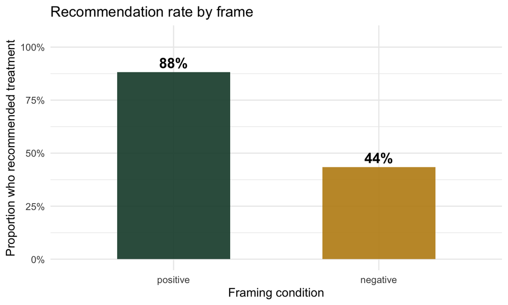

## 3.5 Step 4 — Analysis

Two-proportion z-test: positive vs. negative frame

| Quantity | Value |
| --- | --- |
| Test statistic (z) | 2.89 |
| p-value | 0.0038 |
| 90% CI lower | 0.234 |
| 90% CI upper | 0.661 |

## 3.6 SSVA Guiding Questions — Experiment 3

**Q1.** How many variables are there, and what type is each?

**Click to reveal answer**

Two variables, and **both** are categorical: framing group (positive / negative) and choice (yes / no). This is different from Experiments 1 and 2, where the response was quantitative.

**Q2.** What are the response and explanatory variables?

**Click to reveal answer**

- **Explanatory**: framing condition (positive vs. negative) — categorical.
- **Response**: recommendation (yes vs. no) — categorical, binary. Because the response is binary, we summarize each group with a **proportion** rather than a mean.

**Q3.** What does the bar chart show? Which frame produced a higher recommendation rate?

**Click to reveal answer**

Each bar shows the proportion of students in that framing group who said “yes.” A taller bar means a higher recommendation rate. Compare the heights: the gap between the two bars is the observed difference in sample proportions, which is our point estimate for the actual difference in population proportions.

**Q4.** For categorical data like this, we don’t compute a mean and SD. What summary statistics *do* we use, and why?

**Click to reveal answer**

For a binary categorical variable, the relevant summaries are the **count** of each category and the **proportion** that falls in one category (e.g., “yes”). The proportion $\hat{p}$ plays the role of the mean for binary data — it’s the average of 1s and 0s if you code yes = 1, no = 0. The variability is implicit in $\hat{p}(1-\hat{p})$, so we don’t need to report an SD separately.

**Q5.** Based on SSVA alone, what is your initial conclusion about whether framing affects recommendations?

**Click to reveal answer**

If the two proportions are noticeably different (e.g., 75% vs. 45%), SSVA suggests framing matters. If they’re very close (e.g., 65% vs. 62%), SSVA suggests framing might not matter much. The test will tell us whether any observed gap is bigger than we’d expect by random chance alone.

## 3.7 Independent Conceptual Questions — Experiment 3

**C1.** What is the statistical question?

**Click to reveal answer**

Is the population proportion of students who would recommend the treatment different under positive framing compared to negative framing?

**C2.** What is the population of interest?

**Click to reveal answer**

All Cal Poly students who could plausibly take this course. (Broader populations like “all adults” or “all patients” require a much bigger generalization leap and are not well supported by a class-section sample.)

**C3.** What is the sample?

**Click to reveal answer**

The students in this STAT 252 section who participated in the framing experiment.

**C4.** What is the observational unit?

**Click to reveal answer**

An individual student.

**C5.** Describe all variables in the study.

**Click to reveal answer**

- **group** — categorical (positive / negative) — explanatory
- **choice** — categorical binary (yes / no) — response

**C6.** What potential confounding variables exist?

**Click to reveal answer**

Because the groups are formed by random assignment, most confounders balance out on average. But: students’ prior exposure to the scenario, their personal experience with medical decisions, their reading speed (if some students didn’t read the scenario carefully), and social influence if students near each other compared their scenarios before choosing. Random assignment handles most baseline differences but can’t fully eliminate these situational factors.

**C7.** Is this an experiment or an observational study?

**Click to reveal answer**

**Experiment.** Students were randomly assigned by the app to one of the two framing conditions — they did not choose which scenario to read.

**C8.** What design improvements could enhance the study?

**Click to reveal answer**

Improvements: (1) prevent students from seeing each other’s scenarios (physical separation or simultaneous reveal); (2) include additional framing conditions to test how the effect scales (e.g., 99% vs. 1%); (3) add follow-up questions to check whether students noticed the framing manipulation; (4) replicate across different medical scenarios to show the effect isn’t specific to one context; (5) recruit a more diverse sample than a single class section.

**C9.** State the null and alternative hypotheses.

**Click to reveal answer**

**In words:** $H_0$: the population proportion of students who recommend the treatment is the same under both framings. $H_a$: the population proportions differ.

**In symbols:** $H_0:\ p_{\text{positive}} - p_{\text{negative}} = 0$ vs. $H_a:\ p_{\text{positive}} - p_{\text{negative}} \neq 0$.

**C10.** Based on the test statistic and p-value, what do you conclude about $H_0$?

**Click to reveal answer**

If p < 0.10, reject $H_0$ — we have evidence that framing affects recommendation rates. If p ≥ 0.10, fail to reject — the data are consistent with no framing effect. State the conclusion in the context of the medical scenario.

**C11.** If the confidence interval were not given, could you infer whether 0 is inside it from the test decision?

**Click to reveal answer**

Yes. If you rejected $H_0$ at the 10% level, the 90% CI for $p_{\text{positive}} - p_{\text{negative}}$ will not contain 0. If you failed to reject, it will contain 0. The test and the interval always agree.